# HW 05: County Health

Model Comparison/Evaluation + Outliers

In this homework, you’ll use simple and multiple linear regression to analyze the relationship between the number of doctors in a county, the number of beds, and the number of hospitals.

# Learning goals

By the end of the homework you will be able to…

- compare models using $R^2$ and RMSE
- transform observations to improve model fit
- talk about outliers
- fit a model with two predictors

# Getting started

- Go to [RStudio](https://rstudio.collegeofidaho.edu) and login with your College of Idaho Email and Password.
- Make a subfolder in your `hw` directory to store this homework.
- Log into [Canvas](https://cofi.instructure.com/courses/17093/assignments/202863), navigate to Homework 5 and upload the `hw-05.qmd` file into the folder your just made.

# Packages

We’ll use the following packages in this homework.

```r
library(tidyverse)
library(broom)
library(yardstick)
library(ggformula)
library(knitr)
library(patchwork)
library(Stat2Data)
library(GGally)
# add more packages as needed
```

## Data: County Health

The data set for this homework is from the `Stat2Data` R package which is the companion package for this course’s textbook. It is the same data set that we used in AE-08. The data was originally generated by the American Medical Association and concerns the availability of health care in counties in the United States. You can find information [here](https://cran.r-project.org/web/packages/Stat2Data/Stat2Data.pdf) by searching for the County Health Resources dataset.

```r
data("CountyHealth") # Loads the data from the package
glimpse(CountyHealth)
```

```
Rows: 53
Columns: 4
$ County    <fct> "Bay, FL                             ", "Beaufort, NC       …
$ MDs       <int> 351, 95, 260, 2797, 769, 42, 13, 20, 2981, 83, 56, 37, 320, …
$ Hospitals <int> 3, 2, 2, 11, 5, 2, 2, 2, 7, 3, 2, 2, 2, 2, 8, 2, 3, 6, 12, 5…
$ Beds      <int> 605, 134, 567, 1435, 976, 245, 33, 65, 1462, 100, 179, 42, 3…
```

It is relatively easy to count the number of hospitals a county has, whereas counting the number of doctors is much more difficult. We’d like to build a linear model to predict the number of doctors, contained in the variable `MDs`, from the number of hospitals, `Hospitals` and the number of beds, `Beds`.

## Exercise 1

Describe was an observational unit represents for this data set. How many are there?

The 53 rows represents the observational unit in the data set.

## Exercise 2

In Example 1.7 of Stat2, they consider a simple linear model to predict the number of doctors (`MDs`) from the number of hospitals (`Hospitals`) in a metropolitan area. In that example, they found that a square root transformation on the response variable produced a more linear relationship. Create a new variable in the `CountyHealth` data frame called `sqrtMDs`. Hint: use the `sqrt` function inside the `mutate` function.

```r
CountyHealth <- CountyHealth |>
  mutate(sqrtMDs = sqrt(MDs))
head(CountyHealth)
```

```
                                County  MDs Hospitals Beds   sqrtMDs
1 Bay, FL                               351         3  605 18.734994
2 Beaufort, NC                           95         2  134  9.746794
3 Beaver, PA                            260         2  567 16.124515
4 Bernalillo, NM                       2797        11 1435 52.886671
5 Bibb, GA                              769         5  976 27.730849
6 Clinton, PA                            42         2  245  6.480741
```

## Exercise 3

Use the function `ggpairs` from the package `GGally` to generate a grid scatter plots and correlations. Note that you will need to select the variables you want to use. Which explanatory variable (`Hospitals` or `Beds`) has the highest correlation with `SqrtMDs`? Is this consistent with your visual assessment?

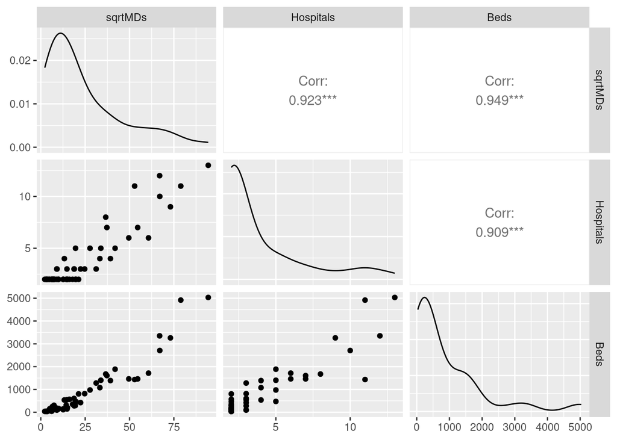

```r
ggpairs(CountyHealth, columns=c("sqrtMDs","Hospitals","Beds"))
```

## Exercise 4

Fit a simple linear model using `SqrtMDs` as the response variable and `Hospitals` as the predictor. You may use `sqrt(MDs)` in your `lm` call instead of `SqrtMDs` if you like. How much of the variability in the `SqrtMDs` values is explained by `Hospitals`? How much of the variability in `MDs` is explained by the model you just fit. To figure this out:

```r
model_hospitals <- lm(sqrt(MDs) ~ Hospitals, data = CountyHealth)
```

1. Augment your model.

```r
augmented_model <- augment(model_hospitals)
head(augmented_model) |>
  kable()
```

| sqrt(MDs) | Hospitals | .fitted | .resid | .hat | .sigma | .cooksd | .std.resid |
| --- | --- | --- | --- | --- | --- | --- | --- |
| 18.734994 | 3 | 17.87577 | 0.8592277 | 0.0208553 | 8.743158 | 0.0001071 | 0.1002937 |
| 9.746794 | 2 | 10.99940 | -1.2526078 | 0.0271321 | 8.742176 | 0.0003000 | -0.1466821 |
| 16.124516 | 2 | 10.99940 | 5.1251133 | 0.0271321 | 8.713088 | 0.0050226 | 0.6001578 |
| 52.886671 | 11 | 72.88668 | -20.0000077 | 0.1251721 | 8.204464 | 0.4363857 | -2.4697773 |
| 27.730849 | 5 | 31.62849 | -3.8976452 | 0.0211792 | 8.726252 | 0.0022400 | -0.4550296 |
| 6.480741 | 2 | 10.99940 | -4.5186615 | 0.0271321 | 8.719985 | 0.0039043 | -0.5291415 |

1. Convert the fitted and observed response variables back to number of MDs rather than square-root of the number of MDs.

```r
augmented_model <-augmented_model|>
  mutate(fitted_MDs =.fitted^2, observed_MDs = `sqrt(MDs)`^2)
```

1. Compute the $R^2$.

```r
rsq(data=augmented_model, truth = `sqrt(MDs)`,estimate=.fitted)
```

```
# A tibble: 1 × 3
  .metric .estimator .estimate
  <chr>   <chr>          <dbl>
1 rsq     standard       0.852
```

The R-squared value of 0.852 indicates that 85.2% of the variability in the square root of the number of MDs is explained by the number of hospitals. However, this does not directly translate to the variability in the actual number of MDs because R-squared measures the proportion of variance explained in the transformed response variable (square root of MDs).

## Exercise 5

Do you think taking the square root of `Beds` would improve this model? Support your argument with plots and/or numbers.

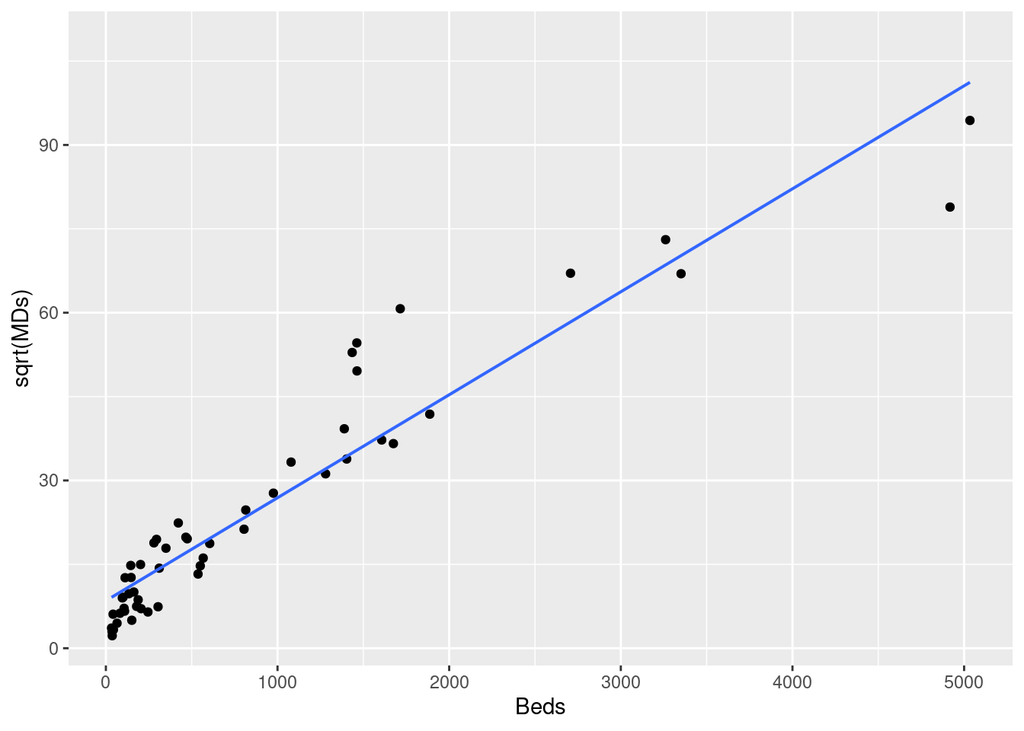

```r
model_hospitals <- lm(sqrt(MDs) ~ Beds, data = CountyHealth)
gf_point(sqrt(MDs)~Beds, data=CountyHealth)|>
  gf_lm()
```

```r
augmented_hospitals <- augment(model_hospitals)
rsq(data= augmented_hospitals, truth = `sqrt(MDs)`,estimate=.fitted)
```

```
# A tibble: 1 × 3
  .metric .estimator .estimate
  <chr>   <chr>          <dbl>
1 rsq     standard       0.901
```

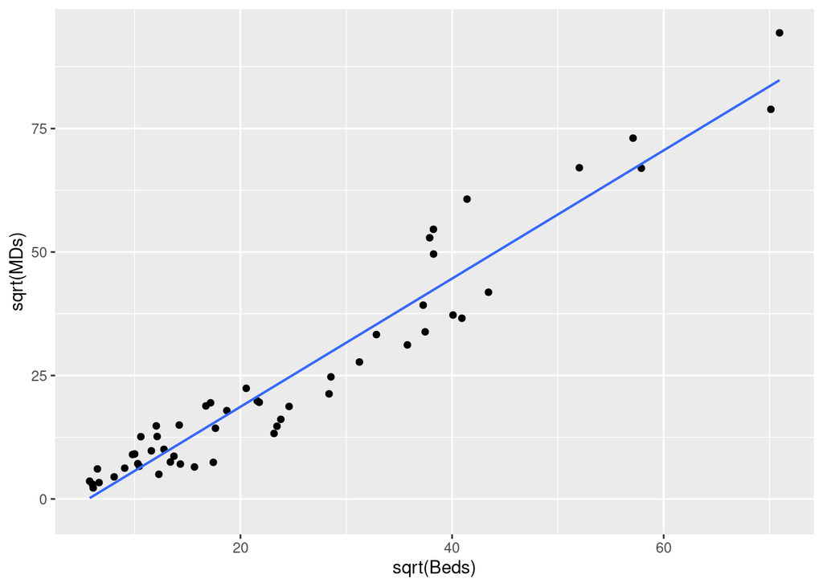

```r
model_hospitals_sqrt <- lm(sqrt(MDs) ~ sqrt(Beds), data = CountyHealth)
gf_point(sqrt(MDs)~sqrt(Beds), data=CountyHealth)|>
  gf_lm()
```

```r
augmented_hospitals_sqrt <- augment(model_hospitals_sqrt)
rsq(data= augmented_hospitals_sqrt, truth = `sqrt(MDs)`,estimate=.fitted)
```

```
# A tibble: 1 × 3
  .metric .estimator .estimate
  <chr>   <chr>          <dbl>
1 rsq     standard       0.929
```

## Exercise 6

Repeat exercise 4 above with `Beds` as the predictor instead of `Hospitals`.

```r
model_hospitals <- lm(sqrt(MDs) ~ Beds, data = CountyHealth)

augmented_model_hospitals <- augment(model_hospitals)
head(augmented_model_hospitals) |>
  kable()
```

| sqrt(MDs) | Beds | .fitted | .resid | .hat | .sigma | .cooksd | .std.resid |
| --- | --- | --- | --- | --- | --- | --- | --- |
| 18.734994 | 605 | 19.63517 | -0.9001787 | 0.0198808 | 7.153925 | 0.0001671 | -0.1283438 |
| 9.746794 | 134 | 10.96094 | -1.2141470 | 0.0267286 | 7.152963 | 0.0004144 | -0.1737160 |
| 16.124516 | 567 | 18.93534 | -2.8108253 | 0.0201937 | 7.143802 | 0.0016556 | -0.4008199 |
| 52.886671 | 1435 | 34.92097 | 17.9656982 | 0.0235365 | 6.677144 | 0.0793705 | 2.5662659 |
| 27.730849 | 976 | 26.46774 | 1.2631080 | 0.0190354 | 7.152807 | 0.0003144 | 0.1800111 |
| 6.480741 | 245 | 13.00519 | -6.5244463 | 0.0245330 | 7.093828 | 0.0109333 | -0.9324443 |

```r
augmented_model_hospitals  <- augmented_model_hospitals |>
  mutate(fitted_MDs = .fitted^2,
         observed_MDs= `sqrt(MDs)`^2)

rsq(data=augmented_model_hospitals, truth= `sqrt(MDs)`, estimate= .fitted)
```

```
# A tibble: 1 × 3
  .metric .estimator .estimate
  <chr>   <chr>          <dbl>
1 rsq     standard       0.901
```

## Exercise 7

For the model you just fit, are there any high-influence outliers? Justify your answer using something from the lecture on outliers. There appear to be at least two high-leverage points. Which observations are these?

In the scatterplot above, High-leverage points are data points that are far from most of the others along the x-axis. This means they have the potential to pull or influence the regression line significantly. For example, the two points around x≈5000 are high-leverage points because they are far away from where most of the other data points are located. Their position makes them capable of strongly affecting the slope and position of the regression line.

## Exercise 8

Fit a multiple linear model using `SqrtMDs` as the response variable and both `Hospitals` and `Beds` as the predictors. Interpret both slopes and the intercept in the context of the problem.

```r
model_multiple <- lm(sqrt(MDs) ~ Hospitals + Beds, data = CountyHealth)
summary(model_multiple)
```

```
Call:
lm(formula = sqrt(MDs) ~ Hospitals + Beds, data = CountyHealth)

Residuals:
     Min       1Q   Median       3Q      Max
-13.5871  -4.1914  -0.6957   4.0766  20.5490

Coefficients:
            Estimate Std. Error t value Pr(>|t|)
(Intercept) 3.580809   1.740616   2.057 0.044901 *
Hospitals   2.579354   0.708641   3.640 0.000646 ***
Beds        0.012307   0.001846   6.668 1.99e-08 ***
---
Signif. codes:  0 '***' 0.001 '**' 0.01 '*' 0.05 '.' 0.1 ' ' 1

Residual standard error: 6.362 on 50 degrees of freedom
Multiple R-squared:  0.9217,    Adjusted R-squared:  0.9186
F-statistic: 294.4 on 2 and 50 DF,  p-value: < 2.2e-16
```

The slope for Hospitals (2.579) means that for each additional hospital, the square root of the number of MDs increases by about 2.579. The slope for Beds (0.012) means that for each additional bed, the square root of the number of MDs increases by about 0.012. Both slopes show a positive relationship between these factors and the number of MDs.

## Exercise 9

How much of the variation in `MDs` is explained by the model you just fit? Which model would you say is the “best”, given what we’ve learned through the first lecture on multiple linear regression.

## Exercise 10

Using the “best” model, predict the average number of doctors in a metro area with 1,000 beds and 4 hospitals. Report a 95% prediction interval and interpret your results in context.

```r
new_data <- tibble(Beds=1000, Hospitals=4)
prediction <-predict(model_multiple, newdata=new_data, interval="prediction", level=0.95)|>
  kable()
prediction
```

| fit | lwr | upr |
| --- | --- | --- |
| 26.20521 | 13.29991 | 39.11052 |

Using the best model, the predicted square root of the number of doctors in a metro area with 1,000 beds and 4 hospitals is approximately 26.21. The 95% prediction interval ranges from 13.30 to 39.11, meaning we can be 95% confident that the actual square root of the number of doctors will fall within this range.

## Grading

Total points available: 20 points.

| Component | Points |
| --- | --- |
| Ex 1 | 1 |
| Ex 2 | 1 |
| Ex 3 | 2 |
| Ex 4 | 2 |
| Ex 5 | 2 |
| Ex 6 | 2 |
| Ex 7 | 2 |
| Ex 8 | 2 |
| Ex 9 | 2 |
| Ex 10 | 2 |
| Grammar & Writing | 1[^1] |
| Workflow & formatting | 1[^2] |

## Footnotes

[^1]: The “Grammar & Writing” grade is decided based on your grammar and writing. This is typically decided by choosing one of the questions and assessing the writing.
[^2]: The “Workflow & formatting” grade is to assess the reproducible workflow and document format. This includes having a neatly organized document with readable code and your name and the date in the YAML.